# PML Coursera-Project

Daniela Alexander

Thursday, December 18, 2014

## Data Analysis

Information about the data set, the purpose of the experiment and lots of other detals is available from the website here: http://groupware.les.inf.puc-rio.br/har (see the section on the Weight Lifting Exercise Dataset).

### Data

The training data for this project are available here:

https://d396qusza40orc.cloudfront.net/predmachlearn/pml-training.csv

The test data are available here:

https://d396qusza40orc.cloudfront.net/predmachlearn/pml-testing.csv

```r
library(caret)
library(rpart)
library(randomForest)
library(rattle)
```

Let’s get the data from the appropriate files:

```r
training <- read.csv("pml-training.csv")
testing<-read.csv("pml-testing.csv")
dim(training); dim(testing)
```

```
## [1] 19622   160
```

```
## [1]  20 160
```

Training set has 19622 observations and 160 variables; Test set has 20 observations and 160 variables.

### Data transformation and reducing the number of variables used in the model

According to the information of the experiment, the first 7 columns of the data sets are irrelevant for our model, therefore we will remove them from the data sets (remember all data transformations must be applied to both training and testing data sets).

```r
training<-training[, -c(1:7)]
testing<-testing[, -c(1:7)]
```

Getting getting rid of other irrelevant variables = zero covariates, by applying near zero variables method:

```r
set.seed(1969)
nzvv <- nearZeroVar(testing)
training<-training[, -nzvv]
testing<-testing[, -nzvv]
```

There is a column difference between test and train; train has classe, test has problem_id. We’ll get rid of problem_id in test in add classe, so the 2 data sets have an identical set of variables.

```r
testing$problem_id <- NULL
testing$classe<- c(rep("A",20))
##transforming classe into a factor class for uniformity with the training set
testing$classe <- as.factor(testing$classe)
```

## Prediction Model

Our goal is to work through a set of Random Forests models and try to reduce the number of variables to what would be a minimal set. We’re starting the modeling with a relatively high number of variables (columns = 53).

### Model Building and Cross-validation

```r
modFit <-  randomForest(classe ~ ., data = training, importance = TRUE)
predTrain <- predict(modFit, newdata=training, type = "class")
confusionMatrix(predTrain, training$classe)$overall[1]
```

```
## Accuracy
##        1
```

Accuracy on this model is 1, very good, so in theory we could stop here. Let’s advance a bit more in reducing the number of variables though. Let’s start by ordering the important variables by Gini index value and then trying various models with different numbers of variables to find the minimal boundary where the Accuracy becomes 1 (which would give us the minimal number of variables to use in the model).

```r
importantVariables <- importance(modFit)
summary(importantVariables[,"MeanDecreaseGini"])
```

```
##    Min. 1st Qu.  Median    Mean 3rd Qu.    Max.
##   55.16  130.40  232.70  298.30  359.40 1251.00
```

We can see a lot of variance among the predictors. Looping through various models (with variables from 2 to 1/2 * our current number of variables):

```r
indexedByGini<-importantVariables[order(importantVariables[,"MeanDecreaseGini"],decreasing=TRUE),"MeanDecreaseGini"]
accurate<-rep(0, 18)
for (i in c(1:18)) {
    trainData <- training[, c(names(indexedByGini[1:i+1]), "classe")]
    trialModel <- randomForest(classe ~ ., data = trainData, importance=TRUE)
    trialPrediction <- predict(trialModel, newdata = trainData, type ="class")
    accurate[i] <- confusionMatrix(trialPrediction, trainData$classe)$overall[1]
}
```

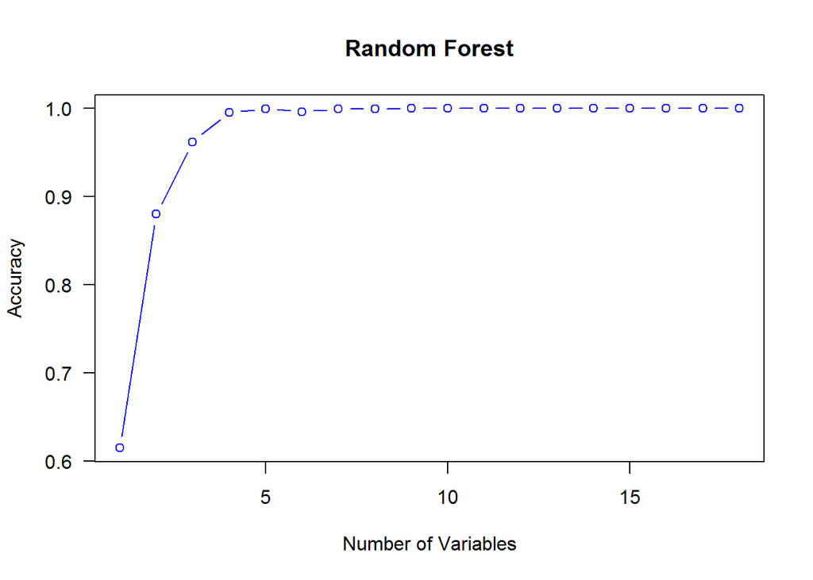

```r
plot(c(1:18), accurate, type="b", las=1, col="blue",
     xlab="Number of Variables", ylab="Accuracy", main="Random Forest")
```

### Model - final choice

Let’s build a Random Forests model with the first 10 variables in the order of Gini index importance.

```r
trainTemp = training[ , c(names(indexedByGini[1:10]), "classe")]
modelFit <- randomForest(classe ~ ., data = trainTemp, importance=TRUE)
```

Variables used:

```r
names(importance(modelFit)[,"MeanDecreaseGini"])
```

```
##  [1] "roll_belt"         "yaw_belt"          "pitch_forearm"
##  [4] "magnet_dumbbell_z" "pitch_belt"        "magnet_dumbbell_y"
##  [7] "roll_forearm"      "magnet_dumbbell_x" "accel_dumbbell_y"
## [10] "roll_dumbbell"
```

Our model’s statistics:

```r
pred<-predict(modelFit, newdata=trainTemp)
confusionMatrix(pred, trainTemp$classe)
```

```
## Confusion Matrix and Statistics
##
##           Reference
## Prediction    A    B    C    D    E
##          A 5580    0    0    0    0
##          B    0 3797    0    0    0
##          C    0    0 3422    0    0
##          D    0    0    0 3216    0
##          E    0    0    0    0 3607
##
## Overall Statistics
##
##                Accuracy : 1
##                  95% CI : (0.9998, 1)
##     No Information Rate : 0.2844
##     P-Value [Acc > NIR] : < 2.2e-16
##
##                   Kappa : 1
##  Mcnemar's Test P-Value : NA
##
## Statistics by Class:
##
##                      Class: A Class: B Class: C Class: D Class: E
## Sensitivity            1.0000   1.0000   1.0000   1.0000   1.0000
## Specificity            1.0000   1.0000   1.0000   1.0000   1.0000
## Pos Pred Value         1.0000   1.0000   1.0000   1.0000   1.0000
## Neg Pred Value         1.0000   1.0000   1.0000   1.0000   1.0000
## Prevalence             0.2844   0.1935   0.1744   0.1639   0.1838
## Detection Rate         0.2844   0.1935   0.1744   0.1639   0.1838
## Detection Prevalence   0.2844   0.1935   0.1744   0.1639   0.1838
## Balanced Accuracy      1.0000   1.0000   1.0000   1.0000   1.0000
```

And a view of our model:

```r
print(modelFit)
```

```
##
## Call:
##  randomForest(formula = classe ~ ., data = trainTemp, importance = TRUE)
##                Type of random forest: classification
##                      Number of trees: 500
## No. of variables tried at each split: 3
##
##         OOB estimate of  error rate: 1.02%
## Confusion matrix:
##      A    B    C    D    E class.error
## A 5548   15   13    4    0 0.005734767
## B   22 3715   44   16    0 0.021595997
## C    3   24 3379   16    0 0.012565751
## D    0    2   18 3193    3 0.007151741
## E    0    7    8    5 3587 0.005544774
```

```r
confTable<-confusionMatrix(pred,trainTemp$classe)
errorRate<-1-sum(diag(confTable$table))/sum(confTable$table)
errorRate
```

```
## [1] 0
```

### Verification of our model

Finally, we perform the verification on the test set (which went through the same data transformations we applied to the training data set):

```r
testTemp = testing[ , c(names(indexedByGini[1:10]), "classe")]
predTest <- predict(modelFit, newdata=testTemp)
predTest
```

```
##  1  2  3  4  5  6  7  8  9 10 11 12 13 14 15 16 17 18 19 20
##  B  A  B  A  A  E  D  B  A  A  B  C  B  A  E  E  A  B  B  B
## Levels: A B C D E
```

The results were verified with the submission part of the asignment and passed 100%.